# Access Data and Metadata from ‘Microsoft’ ‘Power BI’ Documents

Don Diproto

21/10/2020

The ‘pbixr’ package enables one to extract ‘Power Query M’ formulas (https://docs.microsoft.com/en-us/power-query/) ‘Data Analysis Expressions’ queries (‘DAX’, https://docs.microsoft.com/en-us/dax/) and their properties, report layout and style, and data and data models.

‘Microsoft’ ‘Power BI’ is a big deal – more than 200,000 organisations in 205 countries were reported as using it in [February 16, 2017](https://web.archive.org/web/20170906094058/https://powerbi.microsoft.com/en-us/blog/gartner-positions-microsoft-as-a-leader-in-bi-and-analytics-platforms-for-ten-consecutive-years/).

With extensive use of ‘Power BI’ and production of ‘.pbix’ files, managing and analysing ‘.pbix’ files can be challenging for individuals and organisations.

The `pbixr` package in R has several functions that can help.

# Usage

The sample ‘.pbix’ used to demonstrate features of `pbixr` came from an [online ‘Power BI’ tutorial](https://web.archive.org/web/20170325143253/https://sqlkover.com/open-source-power-bi-desktop-workshop/), stored [here](https://github.com/KoenVerbeeck/PowerBI-Course/raw/master/pbix/TopMovies.pbix). It was available under an [MIT Licence](https://github.com/KoenVerbeeck/PowerBI-Course/blob/master/LICENSE). Due to licencing, this package could not be demonstrated on other ‘.pbix’ files available from: [MS](https://github.com/microsoft/powerbi-desktop-samples/tree/master/Monthly%20Desktop%20Blog%20Samples/2019), [Devin Knight](https://devinknightsql.com/category/power-bi-custom-visuals/) and [Adam Aspin](https://github.com/Apress/pro-power-bi-desktop), author of ‘Pro Power BI Desktop’.

```r
# 'suppressMessages' is used to hide messages
suppressMessages(library(pbixr))

# Helpers for this vignette
suppressMessages(library(RCurl))
suppressMessages(library(ggplot2))
suppressMessages(library(ggraph))
suppressMessages(library(igraph))
suppressMessages(library(imager))
suppressMessages(library(tidyr))
suppressMessages(library(formatR))
```

```r
temp_dir <- file.path(tempdir(), "vig")
if (!dir.exists(temp_dir)) {
    dir.create(temp_dir)
}
sample_file_name <- "sample_vig.pbix"
path_file_sample <- file.path(temp_dir, sample_file_name)
parent_temp_dir <- dirname(temp_dir)
existing_file <- list.files(parent_temp_dir,
pattern = sample_file_name, recursive = TRUE, full.names = TRUE)
if (length(existing_file) == 0) {
   url_pt1 <- "https://github.com/KoenVerbeeck/PowerBI-Course/blob/"
   url_pt2 <- "master/pbix/TopMovies.pbix?raw=true"
   url <- paste0(url_pt1, url_pt2)
   req <- download.file(url, destfile = path_file_sample, mode = "wb")
} else {
   path_file_sample <- existing_file[1]
}

# Licence ----------------------------------------------------------------------
# Licence associated with the sample .pbix file

# MIT License
#
# Copyright (c) 2017 KoenVerbeeck
#
# Permission is hereby granted, free of charge, to any person obtaining a copy
# of this software and associated documentation files (the "Software"), to deal
# in the Software without restriction, including without limitation the rights
# to use, copy, modify, merge, publish, distribute, sublicense, and/or sell
# copies of the Software, and to permit persons to whom the Software is
# furnished to do so, subject to the following conditions:
#
# The above copyright notice and this permission notice shall be included in all
# copies or substantial portions of the Software.
#
# THE SOFTWARE IS PROVIDED "AS IS", WITHOUT WARRANTY OF ANY KIND, EXPRESS OR
# IMPLIED, INCLUDING BUT NOT LIMITED TO THE WARRANTIES OF MERCHANTABILITY,
# FITNESS FOR A PARTICULAR PURPOSE AND NONINFRINGEMENT. IN NO EVENT SHALL THE
# AUTHORS OR COPYRIGHT HOLDERS BE LIABLE FOR ANY CLAIM, DAMAGES OR OTHER
# LIABILITY, WHETHER IN AN ACTION OF CONTRACT, TORT OR OTHERWISE, ARISING FROM,
# OUT OF OR IN CONNECTION WITH THE SOFTWARE OR THE USE OR OTHER DEALINGS IN THE
# SOFTWARE.
```

# Analysis

Two broad areas of the sample were explored with `pbixr`:

- metadata
  - sample contents, including images and embedded images
  - queries, including Power Query M formulas and DAX, and associated characteristics
  - sample layout, including position of visual containers, report names and filters
- data
  - executing DAX and MDX queries to gather data from the sample and understand the data model

## Metadata

### What was in the sample?

`f_get_pbix_info` was used to see the contents of the sample.

```r
# File path of the sample
input_pbix <- path_file_sample
pbi_content <- f_get_pbix_info(input_pbix)
pbi_content_names <- pbi_content$Name
# Identify exentsions
pbi_content_types <- unique(tools::file_ext(pbi_content_names))
# Show content
# Make the size look pretty
biggest_file <- max(as.numeric(gsub("[^0-9]*","",pbi_content$Length)))
pbi_content$Length <- prettyNum(pbi_content$Length, big.mark = ",")
knitr::kable(pbi_content)
```

| Name | Length | Date |
| --- | --- | --- |
| Version | 8 | 2017-05-22 16:37:00 |
| [Content_Types].xml | 759 | 2017-05-22 16:37:00 |
| DataMashup | 45,654 | 2017-05-22 16:37:00 |
| DataModel | 1,486,848 | 2017-05-22 16:37:00 |
| Report/Layout | 2,795,666 | 2017-05-22 16:37:00 |
| Settings | 12 | 2017-05-22 16:37:00 |
| Metadata | 990 | 2017-05-22 16:37:00 |
| Report/LinguisticSchema | 3,008 | 2017-05-22 16:37:00 |
| DiagramState | 2,394 | 2017-05-22 16:37:00 |
| Report/CustomVisuals/ImgViewerVisual1455487926945/package.json | 1,150 | 2017-05-22 16:37:00 |
| Report/CustomVisuals/ImgViewerVisual1455487926945/resources/icon.png | 408 | 2017-05-22 16:37:00 |
| Report/CustomVisuals/ImgViewerVisual1455487926945/resources/ImgViewerVisual.js | 14,671 | 2017-05-22 16:37:00 |
| Report/CustomVisuals/ImgViewerVisual1455487926945/resources/ImgViewerVisual.css | 679 | 2017-05-22 16:37:00 |
| Report/CustomVisuals/LongTextViewer1453740445633/package.json | 835 | 2017-05-22 16:37:00 |
| Report/CustomVisuals/LongTextViewer1453740445633/resources/LongTextViewer1453740445633.pbiviz.json | 591,274 | 2017-05-22 16:37:00 |
| Report/CustomVisuals/PBI_CV_9053509D_D461_463A_B485_CE9F6AB0F13C/package.json | 752 | 2017-05-22 16:37:00 |
| Report/CustomVisuals/PBI_CV_9053509D_D461_463A_B485_CE9F6AB0F13C/resources/PBI_CV_9053509D_D461_463A_B485_CE9F6AB0F13C.pbiviz.json | 24,938 | 2017-05-22 16:37:00 |
| SecurityBindings | 294 | 2017-05-22 16:37:00 |

The sample contained 18 files written on 22 May 2017. The biggest file was 2,795,666 bytes. The format of the files in the sample varied (xml, json, png, js, css). The format of some these files was not easily identifiable because they didn’t have a suffix (e.g., .png) – they were likely to be compressed or (e.g., ‘DataMashup’) or a sub-directory (e.g., ‘Report/Layout’).

### What did the image in the sample look like?

`f_extract_images` was used to extract the only identifiable stand-alone image (i.e. an image not embedded in another file) in the sample.

[figure not shown]

```r
# Search only for .png files
  image_reg <- "[.]png"
# Get the images
  image_information <- f_extract_images(input_pbix, image_reg)
  image_name <- gsub(".*/", "", image_information[[2]]$Name)
# Plot the first image
  im <- imager::load.image(image_information[[1]])
  plot(im, main = image_name)
```

In this case, there was an image that was white.

The sample included custom visuals, one of which contained an image. `f_get_pbix_fir`, the basis of `f_extract_images`, was used to help extract the image. This image appeared in the ‘Visualisations’ section of ‘Power BI’.

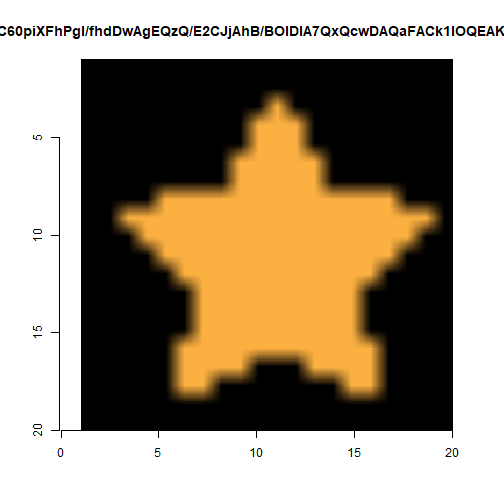

```r
# Get the byte sequence of a first-level file.
# The string is too long to fit nicely for this vignette so I will break it
# and paste it together.
  variable_pt1 <- "Report/CustomVisuals/PBI_CV_9053509D_D461_463A_B485_"
  variable_pt2 <- "CE9F6AB0F13C/resources/PBI_CV_9053509D_D461_463A_B485"
  variable_pt3 <- "_CE9F6AB0F13C.pbiviz.json"
  variable <- paste0(variable_pt1, variable_pt2, variable_pt3)
  raw_img_viewer_visual <- f_get_pbix_fir(path_file_sample, variable)

# Write to a temporary file
  temp_file_2 <- file.path(tempdir(), "pbiviz_1")
  zz <- file(temp_file_2, "wb")
  writeBin(raw_img_viewer_visual, zz)
  close(zz)

# Read temporary file back in
  char_img_viewer_visual <- readLines(temp_file_2, warn =  FALSE)

# Get image data from the relvant line
  image_img_viewer_visual <- gsub(");}", "",
  gsub(".*data:…",
  "", grep("data:…", char_img_viewer_visual, value = TRUE)))

# Decode
  raw_image_img_viewer_visual <- RCurl::base64Decode(image_img_viewer_visual,
  mode = "raw")

# Write to a temporary file
  temp_file_3 <- file.path(tempdir(), "pbiviz_2.png")
  zz <- file(temp_file_3, "wb")
  writeBin(raw_image_img_viewer_visual, zz)
  close(zz)

# Plot
  # Get the name of custom visual for the main title
    plot_title <- paste0("Visual: '",
    gsub(".*:\"", "",
    gsub("\", \"displayName.*", "", char_img_viewer_visual)), "'")
  # Load the image and create the plot
    load_image_img_viewer_visual <- imager::load.image(temp_file_3)
    plot(load_image_img_viewer_visual, main = plot_title)
```

### What Power Query M formulas were used in the sample?

‘DataMashup’ was a compressed file that included the Power Query M formulas in the sample. `f_get_dama_m` was used to extract them.

```r
# Get the query
m_query <- f_get_dama_m(input_pbix, remove_temp = TRUE)
# Show the first ten lines of the query
top_m <- paste0(head(m_query, 10), "\n")
```

The first ten steps of one of the Power Query M formulas looked like this:

```r
cat(top_m)
```

```
#> section Section1;
#>
#>  shared TopMovies = let
#>      Source = Excel.Workbook(File.Contents("D:\SQLServer_Community\Power BI Open Source Training\Top250Movies.xlsx"), null, true),
#>      MovieList_Sheet = Source{[Item="MovieList",Kind="Sheet"]}[Data],
#>      #"Changed Type" = Table.TransformColumnTypes(MovieList_Sheet,{{"Column1", type text}}),
#>      #"Promoted Headers" = Table.PromoteHeaders(#"Changed Type", [PromoteAllScalars=true]),
#>      #"Split on Point" = Table.SplitColumn(#"Promoted Headers","Movies",Splitter.SplitTextByEachDelimiter({"."}, QuoteStyle.Csv, false),{"Rank", "Title"}),
#>      #"Changed Type1" = Table.TransformColumnTypes(#"Split on Point",{{"Rank", Int64.Type}, {"Title", type text}}),
#>      #"Trimmed Text" = Table.TransformColumns(#"Changed Type1",{{"Title", Text.Trim}}),
```

The ‘DataMashup’ file also included an .xml file, which contained metadata associated with the Power Query M formulas. `f_get_dama`, `f_get_dama_index`, `f_get_dama_file`, `f_get_dama_xml_details` and `f_get_dama_xml` were used to access the .xml file in the DataMashup file and `f_get_dama_xml_data` was used to get the metadata of the Power Query M formulas.

```r
# Get details of .xml files included in the DataMashup file
xml_details <- f_get_dama_xml_details(input_pbix)
# Identify the start and end bytes of the .xml file we want from the
# DataMashup file
xml_start <- (xml_details[[1]][1] / 2) + 1
xml_end <- xml_details[[3]][1]
# Get the desired .xml file from DataMashup file
input_xml <- f_get_dama_xml(input_pbix, xml_start, xml_end)
# Get metadata from the the desired .xml file
get_xml_data <- f_get_dama_xml_data(input_xml)
```

### What metadata existed for all Power Query M formula in the sample?

4 metadata variables existed for all Power Query M formulas.

```r
# Show content
knitr::kable(get_xml_data[[1]])
```

| query | type | value |
| --- | --- | --- |
| AllFormulas | Relationships | sAAAAAA== |
| AllFormulas | QueryGroups | sAAAAAA== |
| AllFormulas | IsRelationshipDetectionEnabled | sFalse |
| AllFormulas | RunBackgroundAnalysis | sFalse |

### What metadata existed for each Power Query M formula in the sample?

```r
# Show content of first query
show_first_query <- get_xml_data[[2]] %>%
  filter(query == "Section1/Actors%20Bridge")
knitr::kable(show_first_query)
```

| query | type | value |
| --- | --- | --- |
| Section1/Actors%20Bridge | IsDirectQuery | l0 |
| Section1/Actors%20Bridge | NameUpdatedAfterFill | l1 |
| Section1/Actors%20Bridge | ResultType | sTable |
| Section1/Actors%20Bridge | BufferNextRefresh | l0 |
| Section1/Actors%20Bridge | FillColumnNames | s[“Title”,“Actors”] |
| Section1/Actors%20Bridge | RelationshipInfoContainer | s{“columnCount”:2,“keyColumnNames”:[],“queryRelationships”:[],“columnIdentities”:[“Section1/Actors Bridge/Unpivoted Columns.{Title,0}”,“Section1/Actors Bridge/Trimmed Text.{Actors,1}”],“ColumnCount”:2… |
| Section1/Actors%20Bridge | LastAnalysisServicesFormulaText | s{“IncludesReferencedQueries”:true,“RootFormulaText”:“letSource = ExtraMovieInfo,#"Removed Other Columns" = Table.SelectColumns(Source,{"Actors", "Title"}),#"Split Column by Delimiter" = Table.SplitCo… |
| Section1/Actors%20Bridge | IsLastAnalysisServicesFormulaTextCollection | l1 |
| Section1/Actors%20Bridge | LoadedToAnalysisServices | l1 |

### What steps existed for each Power Query M formula?

```r
# Show content of first query
knitr::kable(data.frame(step =
grep("Section1/Actors%20Bridge", get_xml_data[[3]], value = TRUE)))
```

| step |
| --- |
| Section1/Actors%20Bridge |
| Section1/Actors%20Bridge/Source |
| Section1/Actors%20Bridge/Removed%20Other%20Columns |
| Section1/Actors%20Bridge/Split%20Column%20by%20Delimiter |
| Section1/Actors%20Bridge/Reordered%20Columns |
| Section1/Actors%20Bridge/Changed%20Type |
| Section1/Actors%20Bridge/Unpivoted%20Columns |
| Section1/Actors%20Bridge/Removed%20Columns |
| Section1/Actors%20Bridge/Trimmed%20Text |

### What was the layout of the sample?

`f_read_layout` was used to read Layout in the Report sub-directory.

```r
gsub__1 <- paste0(".*sections")
gsub__2 <- "{\"id\":0,\"sections"
# Run the function
get_layout <- f_read_layout(path_file_sample, gsub__1, gsub__2)
```

```
#> An error occured reading without data exclusion. The file was read with data exclusion: gsub(".*sections","{"id":0,"sections", ...)
```

An encoding issue was encountered with Layout, which meant that some of the data in Layout was excluded so that it could be loaded into R. This issue was investigated by unzipping the sample and opening ‘Layout’ in a text editor.

### What were the report names of the sample?

```r
computer_name <- get_layout$sections$name
human_name <- get_layout$sections$displayName
reportNames <- data.frame(computer_name = computer_name,
human_name = human_name)
knitr::kable(reportNames)
```

| computer_name | human_name |
| --- | --- |
| ReportSection | OverviewTopMovies |
| ReportSection2 | AnalysisByGenre |
| ReportSection1 | AnalysisByRated |
| ReportSection3 | Clustering |
| ReportSection5 | TimeSlicer |
| ReportSection4 | Grouping,CondForm&others |
| ReportSection6 | Binning |
| ReportSection9 | Numericslicer+Matrix |
| ReportSection7 | DAX |
| ReportSection8 | QuickMeasures |

Note that the human readable names of a report identified in the table above didn’t include white spaces. When viewed in ‘Power BI’, for example, the first report was called ‘Overview Top Movies’ not ‘OverviewTopMovies’.

### Which reports included filters in the sample?

This code was used to identify filters affecting a visual.

```r
json_sect <- get_layout$sections
visual_containers <- json_sect$visualContainers
filter_index <- which(unlist(lapply(lapply(lapply(visual_containers,
function(x)colnames(x)), function(z) grep("filters", z)), length)) > 0)
json_sect$displayName[filter_index]
```

```
#> [1] "AnalysisByGenre"
#> [2] "Grouping,CondForm&others"
```

On the ‘Analysis By Genre’ report, for example, ‘Music (’Genre’)’ was exlcuded from the ‘Count of Title By Genre’ visual.

### Where were all the visual containers positioned in the first report of the sample?

This code was used to show the top left corner of each visual container on a report.

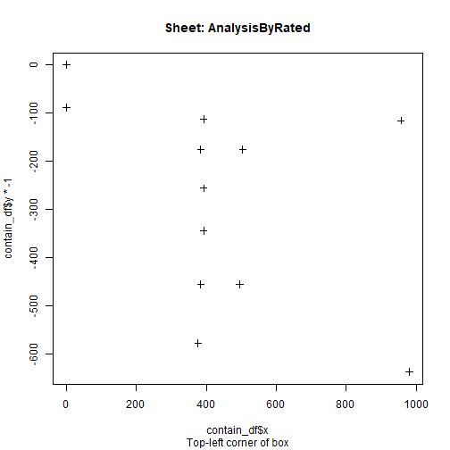

```r
contain_df <- visual_containers[[1]]
plot(contain_df$x, contain_df$y * -1,
main = paste0("Sheet: ", as.character(names[3, 2])),
sub = "Top-left corner of box", pch = 3)
```

### What were the characteristics of one of the visual containers in the first report of the sample?

```r
jsonlite::prettify(contain_df[11, "dataTransforms"])
```

```
#> {
#>     "objects": {
#>         "TextScrollDetail": [
#>             {
#>                 "properties": {
#>                     "fontSize": {
#>                         "expr": {
#>                             "Literal": {
#>                                 "Value": "14D"
#>                             }
#>                         }
#>                     }
#>                 }
#>             }
#>         ]
#>     },
#>     "projectionOrdering": {
#>         "Category": [
#>             0
#>         ]
#>     },
#>     "queryMetadata": {
#>         "Select": [
#>             {
#>                 "Restatement": "Plot",
#>                 "Name": "IMDBTop250.Plot",
#>                 "Type": 2048
#>             }
#>         ]
#>     },
#>     "visualElements": [
#>         {
#>             "DataRoles": [
#>                 {
#>                     "Name": "Category",
#>                     "Projection": 0,
#>                     "isActive": false
#>                 }
#>             ]
#>         }
```

[output cut: 11 more lines]

```
#>             },
#>             "expr": {
#>                 "Column": {
#>                     "Expression": {
#>                         "SourceRef": {
#>                             "Entity": "TopMovies"
#>                         }
#>                     },
#>                     "Property": "Plot"
#>                 }
#>             }
#>         }
#>     ]
#> }
#>
```

## Data

Given that data wasn’t identified elsewhere, ‘DataModel’ was the likely place that data was held. The file started with `STREAM_STORAGE_SIGNATURE_)!@#$%^&*", which was consistent with a [[MS-XLDM]: Spreadsheet Data Model File Format](https://docs.microsoft.com/en-us/openspecs/office_file_formats/ms-xldm/8c62e8ce-f605-488d-81e9-4ecdb7686a52).

`pbixr` did not include a function to get data by reading ‘DataModel’. However, it did include a function, `f_query_datamodel`, to access data via a local instance of ‘Microsoft’ ‘Analysis Services’. `f_get_connections` was used to identify the port of the ‘Analysis Services’ connection. [This document](https://web.archive.org/web/20180819200620/http://biinsight.com/connect-to-power-bi-desktop-model-from-excel-and-ssms/) was considered helpful. `f_query_datamodel` and `f_get_connections` required [‘Microsoft’ ‘PowerShell’](https://en.wikipedia.org/wiki/PowerShell). `f_query_datamodel` could be used to send ‘DAX’ and ‘Multidimensional Expressions’ queries ([‘MDX’](https://docs.microsoft.com/en-us/analysis-services/multidimensional-models/mdx/mdx-query-the-basic-query)).

Two string-escape issues required consideration when sending a query via ‘PowerShell’:

1. Dollar signs were escaped with a backtick (i.e. ‘$’ becomes ‘`$’)
2. Double quotes were escaped with three backslashes and a double quote (i.e. ‘"’ becomes ‘\\\"’).

As a result, subtle differences could be observed between queries sent from `pbixr` and other software, like ‘DaxStudio’.

### What DAX formulas were used in the sample?

A MDX query was executed to bring back a table holding DAX measure formulas.

```r
connections_open <- f_get_connections()
correct_port <- as.numeric(connections_open$ports[1])
connection_db <- paste0("Provider=MSOLAP.8;Data Source=localhost:",
correct_port, ";MDX Compatibility=1")
# Expression to get the DAX queries
# Note the backtick before the dollar sign. This was
# added to escape the dollar sign in PowerShell.
sql_measures <- paste0("select MEASURE_NAME, EXPRESSION, MEASUREGROUP_NAME ",
"from `$SYSTEM.MDSCHEMA_MEASURES")
# Query the analysis service
get_dax <- f_query_datamodel(sql_measures, connection_db)
# Display a result sample
t_data <- t(tail(get_dax, 1))
colnames(t_data) <- "value"
# To improve display of the DAX with kable, I removed new lines and
# tabs that occured in the DAX
knitr::kable(trimws(gsub("\\t", "", gsub("\\n", "", t_data))), )
```

|  | value |
| --- | --- |
| MEASURE_NAME | imdbVotes running total in Title |
| EXPRESSION | CALCULATE(SUM(‘TopMovies’[imdbVotes]),FILTER(CALCULATETABLE(SUMMARIZE(‘TopMovies’, ‘TopMovies’[Rank], ‘TopMovies’[Title]),ALLSELECTED(‘TopMovies’)),ISONORAFTER(‘TopMovies’[Rank], MAX(‘TopMovies’[Rank]… |
| MEASUREGROUP_NAME | TopMovies |

The query above did not include all DAX in the sample. To get more DAX, including DAX for calculated tables, a different query was used.

```r
sql_measures <- paste0("SELECT * From `$SYSTEM.DISCOVER_CALC_DEPENDENCY")
# Query the analysis service
# For presentation, I have chosen a few columns and rows
get_allDax <- f_query_datamodel(sql_measures, connection_db) %>%
  select(OBJECT_TYPE, OBJECT, EXPRESSION) %>%
  group_by(OBJECT_TYPE) %>%
  filter(!grepl("-", OBJECT)) %>%
  filter(nchar(EXPRESSION) > 2) %>%
  unique() %>%
  slice(1) %>%
  ungroup()
# The second row is a CALC_TABLE, which didn't print nicely
# with kable
get_allDax %>%
  slice(1,3,4) %>%
  kable
```

| OBJECT_TYPE | OBJECT | EXPRESSION |
| --- | --- | --- |
| CALC_COLUMN | Year | YEAR([Date]) |
| MEASURE | Avg Rating | AVERAGE(‘TopMovies’[imdbRating]) |
| ROWS_ALLOWED | Germany Only | [Country] = “Germany” |

### What DAX queries were triggered after data were filtered in a report?

The first report, ‘Overview Top Movies’, contained a slicer, movie title, which triggered several queries. These queries were identified in a trace. A few websites provided some hints on using ‘SQL Server Profiler’ to record interactions with ‘Power BI’ ([crossjoin](https://web.archive.org/web/20200426021721/https://blog.crossjoin.co.uk/2020/03/02/connecting-sql-server-profiler-to-power-bi-premium/) and [kasperonbi](https://web.archive.org/web/20190811124052/https://www.kasperonbi.com/how-to-turn-on-ssas-profiler-traces-in-power-bi-desktop/)).

Once the trace was initiated in ‘SQL Server Profiler’, ‘The Godfather’ was selected in the dropdown of the first report (‘Overview Top Movies’) in ‘Power BI’. This triggered a series of events to update the results in the report so that they were related to ‘The Godfather’. The queries underpinning these events were collected in the trace. The queries were extracted to file by switching to ‘SQL Server Profiler’ and selecting File > Export > Extract SQL Server Analysis Services Events > Extract All Queries. The output looked like this:

```
DEFINE VAR __DS0FilterTable =
  TREATAS({"The Godfather"}, 'TopMovies'[Title])

EVALUATE
  TOPN(
    1002,
    CALCULATETABLE(
      DISTINCT('TopMovies'[Poster]),
      KEEPFILTERS(__DS0FilterTable)
    ),
    'TopMovies'[Poster],
    1
  )

ORDER BY
  'TopMovies'[Poster]
DEFINE VAR __DS0FilterTable =
  TREATAS({"The Godfather"}, 'TopMovies'[Title])

EVALUATE
  SUMMARIZECOLUMNS(
    __DS0FilterTable,
    "SumRank", IGNORE(CALCULATE(SUM('TopMovies'[Rank])))
  )
DEFINE VAR __DS0FilterTable =
  TREATAS({"The Godfather"}, 'TopMovies'[Title])

EVALUATE
  TOPN(
    101,
    CALCULATETABLE(
      SUMMARIZE('TopMovies', 'TopMovies'[Released], 'TopMovies'[Rated]),
      KEEPFILTERS(__DS0FilterTable)
    ),
    'TopMovies'[Released],
    1,
    'TopMovies'[Rated],
    1
  )

```

[output cut: 62 more lines]

```
  TREATAS({"The Godfather"}, 'TopMovies'[Title])

EVALUATE
  TOPN(
    101,
    CALCULATETABLE(
      DISTINCT('TopMovies'[Director]),
      KEEPFILTERS(__DS0FilterTable)
    ),
    'TopMovies'[Director],
    1
  )

ORDER BY
  'TopMovies'[Director]
```

Two types of changes were made to this code to run it via `pbixr`:

1. Escape double quotes
2. Remove duplicate define statements.

The query was run from R, returning a list of results related to ‘The Godfather’.

```r
traceQuery <- paste0(
"DEFINE ",
"VAR __DS0FilterTable = ",
"  TREATAS({\\\"\\\"The Godfather\\\"\\\"}, 'TopMovies'[Title])",
"",
"EVALUATE",
"  TOPN(",
"    1002,",
"    CALCULATETABLE(",
"      DISTINCT('TopMovies'[Poster]),",
"      KEEPFILTERS(__DS0FilterTable)",
"    ),",
"    'TopMovies'[Poster],",
"    1",
"  )",
"",
"ORDER BY",
"  'TopMovies'[Poster]",
"",
"EVALUATE",
"  SUMMARIZECOLUMNS(",
"    __DS0FilterTable,",
"    \\\"\\\"SumRank\\\"\\\", IGNORE(CALCULATE(SUM('TopMovies'[Rank])))",
"  )",
"",
"EVALUATE",
"  TOPN(",
"    101,",
"    CALCULATETABLE(",
"      SUMMARIZE('TopMovies', 'TopMovies'[Released], 'TopMovies'[Rated]),",
"      KEEPFILTERS(__DS0FilterTable)",
"    ),",
"    'TopMovies'[Released],",
"    1,",
"    'TopMovies'[Rated],",
"    1",
"  )",
"",
"ORDER BY",
"  'TopMovies'[Released], 'TopMovies'[Rated]",
"",
"EVALUATE",
"  SUMMARIZECOLUMNS(",
"    __DS0FilterTable,",
"    \\\"\\\"SumIMDBRating_Star\\\"\\\", IGNORE(CALCULATE(SUM('TopMovies'[IMDBRating_Star])))",
"  )",
"",
"EVALUATE",
"  SUMMARIZECOLUMNS(",
"    __DS0FilterTable,",
"    \\\"\\\"SumimdbVotes\\\"\\\", IGNORE(CALCULATE(SUM('TopMovies'[imdbVotes]))),",
"    \\\"\\\"SumRuntime\\\"\\\", IGNORE(CALCULATE(SUM('TopMovies'[Runtime])))",
"  )",
"",
"EVALUATE",
"  SUMMARIZECOLUMNS(",
"    __DS0FilterTable,",
"    \\\"\\\"SumMetascore_Star\\\"\\\", IGNORE(CALCULATE(SUM('TopMovies'[Metascore_Star])))",
"  )",
"",
"EVALUATE",
"  TOPN(",
"    101,",
"    CALCULATETABLE(",
"      SUMMARIZE('TopMovies', 'TopMovies'[Title], 'TopMovies'[Rank]),",
"      KEEPFILTERS(__DS0FilterTable)",
"    ),",
"    'TopMovies'[Rank],",
"    1,",
"    'TopMovies'[Title],",
"    1",
"  )",
"",
"ORDER BY",
"  'TopMovies'[Rank], 'TopMovies'[Title]",
"",
"EVALUATE",
"  TOPN(",
"    1002,",
"    CALCULATETABLE(",
"      DISTINCT('TopMovies'[Plot]),",
"      KEEPFILTERS(__DS0FilterTable)",
"    ),",
"    'TopMovies'[Plot],",
"    1",
"  )",
"",
"ORDER BY",
"  'TopMovies'[Plot]",
"",
"EVALUATE",
"  TOPN(",
"    101,",
"    CALCULATETABLE(",
"      DISTINCT('TopMovies'[Director]),",
"      KEEPFILTERS(__DS0FilterTable)",
"    ),",
"    'TopMovies'[Director],",
"    1",
"  )",
"",
"ORDER BY",
"  'TopMovies'[Director]"
)
# Query the analysis service
getTrace <- f_query_datamodel(traceQuery, connection_db)
# Show the list of results
getTrace
```

```
#> [[1]]
#>                                                                                                                                 TopMovies.Poster.
#> 1 https://images-na.ssl-images-amazon.com/images/M/MV5BNTc0ZDk1YWItZDZiNi00NTdmLWE0MDctNTVhYTRhMDBmZjNjXkEyXkFqcGdeQXVyMjUzOTY1NTc@._V1_SX300.jpg
#>
#> [[2]]
#>   X.SumRank.
#> 1          2
#>
#> [[3]]
#>     TopMovies.Released.
#> 1 24-Mar-72 12:00:00 AM
#>   TopMovies.Rated.
#> 1                R
#>
#> [[4]]
#>   X.SumIMDBRating_Star.
#> 1                   4.6
#>
#> [[5]]
#>   X.SumimdbVotes.
#> 1         1186027
#>   X.SumRuntime.
#> 1           175
#>
#> [[6]]
#>   X.SumMetascore_Star.
#> 1                    5
#>
#> [[7]]
#>   TopMovies.Title.
#> 1    The Godfather
#>   TopMovies.Rank.
#> 1               2
#>
#> [[8]]
#>                                                                                                       TopMovies.Plot.
#> 1 The aging patriarch of an organized crime dynasty transfers control of his clandestine empire to his reluctant son.
#>
#> [[9]]
#>    TopMovies.Director.
#> 1 Francis Ford Coppola
```

### What queries produce visualization data?

A trace was also used to identify queries underpinning visualisation data. After clicking on the ‘Grouping, Cond Form & others’ report, the ‘FlightRecorderCurrent.trc’ trace was opened in ‘SQL Server Profiler’ (the location of the trace was identified with the query below).

```r
queryTraces <- paste0("select * from `$SYSTEM.DISCOVER_TRACES")
getTraces <- f_query_datamodel(queryTraces, connection_db)
getTraces
```

All queries were exported from the trace (just like the previous example), and the block with relevant queries was identified.

```r
queryViz <- paste(
"DEFINE",
"  VAR __ApplyFilterSQDS0 = ",
"    TOPN(",
"      5,",
"      SUMMARIZECOLUMNS('Genre'[Genre], \\\"\\\"Avg_Runtime\\\"\\\", 'TopMovies'[Avg Runtime]),",
"      [Avg_Runtime],",
"      0",
"    )",
"",
"  VAR __DS0Core = ",
"    SUMMARIZECOLUMNS(",
"      ROLLUPADDISSUBTOTAL('Genre'[Genre], \\\"\\\"IsGrandTotalRowTotal\\\"\\\"),",
"      __ApplyFilterSQDS0,",
"      \\\"\\\"MinRank\\\"\\\", CALCULATE(MIN('TopMovies'[Rank])),",
"      \\\"\\\"Avg_Rating\\\"\\\", 'TopMovies'[Avg Rating],",
"      \\\"\\\"Avg_Runtime\\\"\\\", 'TopMovies'[Avg Runtime]",
"    )",
"",
"  VAR __DS0CoreNoInstanceFiltersNoTotals = ",
"    FILTER(KEEPFILTERS(__DS0Core), [IsGrandTotalRowTotal] = FALSE)",
"",
"EVALUATE",
"  TOPN(502, __DS0Core, [IsGrandTotalRowTotal], 0, [MinRank], 1, 'Genre'[Genre], 1)",
"",
"ORDER BY",
"  [IsGrandTotalRowTotal] DESC, [MinRank], 'Genre'[Genre]"
)
getViz <- f_query_datamodel(queryViz, connection_db)
colnames(getViz) <- trimws(gsub("[.]", " ", gsub("X[.]"," ",
colnames(getViz))))
showViz <- getViz %>%
  arrange(IsGrandTotalRowTotal, desc(MinRank))
kable(showViz)
```

| Genre Genre | IsGrandTotalRowTotal | MinRank | Avg_Rating | Avg_Runtime |
| --- | --- | --- | --- | --- |
| Sport | False | 121 | 8.220000 | 134.8000 |
| Music | False | 45 | 8.500000 | 136.0000 |
| Western | False | 9 | 8.483333 | 148.3333 |
| Biography | False | 6 | 8.276000 | 147.1200 |
| History | False | 6 | 8.285000 | 162.8000 |
|  | True | 6 | 8.293878 | 150.2653 |

### How were the data linked in the sample?

The model underpinning the data was identified with several queries.

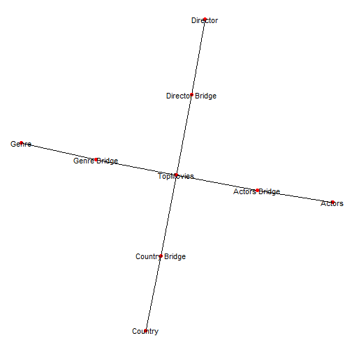

```r
# Get relationships
sql_relationships <- paste0("select FromTableID, FromColumnID, ToTableID,",
" ToColumnID  from `$SYSTEM.TMSCHEMA_RELATIONSHIPS")
get_relationships <- f_query_datamodel(sql_relationships, connection_db)

# Get names of columns
sql_columns <- "select * from `$SYSTEM.TMSCHEMA_COLUMNS"
get_columns <- f_query_datamodel(sql_columns, connection_db) %>%
  mutate(ColumnName = ifelse(nchar(as.character(ExplicitName)) == 0,
  as.character(InferredName), as.character(ExplicitName))) %>%
   select(ColumnID = ID, ColumnName)

# Get names of tables
sql_table <- "select * from `$SYSTEM.TMSCHEMA_TABLES"
get_tables <- f_query_datamodel(sql_table, connection_db) %>%
  select(TableID = ID, TableName = Name)

# Merge things together
get_relationship_names <- get_relationships %>%
  merge(get_tables, by.x = "FromTableID", by.y = "TableID") %>%
  rename(FromTable = TableName) %>%
  merge(get_tables, by.x = "ToTableID", by.y = "TableID") %>%
  rename(ToTable = TableName) %>%
  merge(get_columns, by.x = "FromColumnID", by.y = "ColumnID") %>%
  rename(FromColumn = ColumnName) %>%
  merge(get_columns, by.x = "ToColumnID", by.y = "ColumnID") %>%
  rename(ToColumn = ColumnName) %>%
  select(FromTable, ToTable, FromColumn, ToColumn)

# Make things all characters
# drop table with long name. Doing this just for display purposes here.
get_relationship_names <- get_relationship_names[-5, ] %>%
  mutate(FromTable = as.character(FromTable)) %>%
  mutate(ToTable = as.character(ToTable))

# Plot the results with igraph
c_list <- list()
for (i in 1:nrow(get_relationship_names)) {
  c_list[[i]] <- get_relationship_names[i, 1:2]
}
ed <- as.character(unlist(c_list))
# Use igraph, ggraph, ggplo2 to show preliminary example of data model
g1 <- igraph::graph(edges=ed, directed=F)
ggraph::ggraph(g1, layout = "stress") +
  ggraph::geom_edge_link() +
  ggraph::geom_node_point(size = 2, col = "red") +
  ggraph::geom_node_text(ggplot2::aes(label = name)) +
  ggplot2::theme(panel.background = ggplot2::element_blank())
```

### What data were in the sample?

A DAX query was used to extract all data from the ‘Genre Bridge’ table.

```r
# Use single quotes because table name has a white space
query_GenreBridge <- "evaluate 'Genre Bridge'"
get_data_GenreBridge <- f_query_datamodel(query_GenreBridge, connection_db)
# Display some results
knitr::kable(get_data_GenreBridge[1:5,])
```

| Genre.Bridge.Title. | Genre.Bridge.Genre. |
| --- | --- |
| The Shawshank Redemption | Drama |
| The Godfather | Drama |
| The Godfather: Part II | Drama |
| The Dark Knight | Drama |
| 12 Angry Men | Drama |

A DAX query was used to extract the first five rows of data for each table.

```r
# Build a query by loop through table names and get the first five rows
# Put table names inside single quotes in case
# a white space occurs in the name
createQueriesPt1 <- list()
for (i in seq_along(1:nrow(get_tables))) {
  createQueriesPt1[[i]] <- paste0("evaluate TOPNSKIP(5, 0, '",
  get_tables$TableName[i], "')")
}
createQueriesPt2 <- paste0(unlist(createQueriesPt1), collapse = " ")
get_data_AllTablesAllData <- f_query_datamodel(createQueriesPt2, connection_db)
# Display some results
# For display purposes, I am going to get the first 5 columns of each
# I am only going to display the second table
exampleAllTableResult <- lapply(get_data_AllTablesAllData, function(x) {
  colLength <- ifelse(ncol(x) > 5, 5, ncol(x))
  x[,1:colLength]
  }
)[[2]]
kable(exampleAllTableResult)
```

| TopMovies.Rank. | TopMovies.Title. | TopMovies.Year. | TopMovies.Actors. | TopMovies.Awards. |
| --- | --- | --- | --- | --- |
| 1 | The Shawshank Redemption | 1994 | Tim Robbins, Morgan Freeman, Bob Gunton, William Sadler | Nominated for 7 Oscars. Another 19 wins & 30 nominations. |
| 5 | 12 Angry Men | 1957 | Martin Balsam, John Fiedler, Lee J. Cobb, E.G. Marshall | Nominated for 3 Oscars. Another 16 wins & 8 nominations. |
| 12 | Star Wars: Episode V - The Empire Strikes Back | 1980 | Mark Hamill, Harrison Ford, Carrie Fisher, Billy Dee Williams | Won 1 Oscar. Another 19 wins & 18 nominations. |
| 13 | Forrest Gump | 1994 | Tom Hanks, Rebecca Williams, Sally Field, Michael Conner Humphreys | Won 6 Oscars. Another 39 wins & 65 nominations. |
| 16 | One Flew Over the Cuckoo’s Nest | 1975 | Michael Berryman, Peter Brocco, Dean R. Brooks, Alonzo Brown | Won 5 Oscars. Another 30 wins & 13 nominations. |

An MDX query was used to get the first five movie objects.

```r
query_getTop5Movies <- paste0("select top 5 [MEMBER_NAME] from ",
  "`$System.MDSCHEMA_MEMBERS where [CUBE_NAME]='Model' and ",
  "[LEVEL_UNIQUE_NAME]='[TopMovies].[Title].[Title]'"
  )
get_data_getTop5Movies <- f_query_datamodel(query_getTop5Movies, connection_db)
# Display some results
knitr::kable(get_data_getTop5Movies)
```

| MEMBER_NAME |
| --- |
| The Shawshank Redemption |
| The Godfather |
| The Godfather: Part II |
| The Dark Knight |
| 12 Angry Men |

# Modification

A cautious approach was used: modifications were saved to a new ‘.pbix’, not over an existing ‘.pbix’. It was assumed that dependencies and certification could result in a corrupt ‘.pbix’.

### How was the size of the sample reduced?

The sample was unzipped with `f_unzip_pbix` and `f_clean_under_the_hood` was used to remove ‘DataModel’.

```r
# Create a temporary, modified sample
# File
path_file_sample_mod     <- file.path(temp_dir, "sample_modified.pbix")
if (file.exists(path_file_sample_mod)) {
  file.remove(path_file_sample_mod)
}
# Directory
dir_file_sample_mod <- file.path(temp_dir, "sample_modified")
if (file.exists(dir_file_sample_mod)) {
  unlink(dir_file_sample_mod, recursive = TRUE)
}

f_clean_under_the_hood(path_file_sample, dir_file_sample_mod,
path_file_sample_mod)
unlink(dir_file_sample_mod, recursive = TRUE)

size_ori <- prettyNum(file.info(path_file_sample)$size, big.mark = ",")
size_mod <- prettyNum(file.info(path_file_sample_mod)$size, big.mark = ",")
```

With ‘DataModel’, the sample was 2,196,745 bytes. Without ‘DataModel’, the sample was 701,993 bytes.

Have fun!